# Gender effect in medical study and university positions

ASHP - EL- FR

3/30/2021

# ECN Data

Data on ECN ranking were retrieved on the site of the CNG the 30th march 2021, on the following link https://www.cng.sante.fr/concours-examens/epreuves-classantes-nationales-ecn Menu “Resultats”

Note that year 2005 (not in the site) and 2008 and 2009 are missing, due to inconvenient formatting.

## Gender repartition and temporal trends

Overall, the gender repartition was predominantly females (n=55864, 58.4%) followed by males (n=39861, 41.6%), and this trend was stable over time.

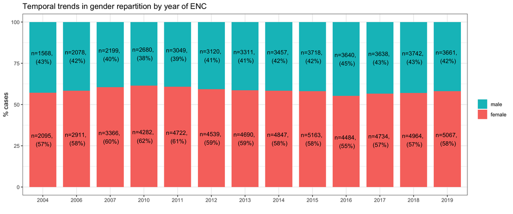

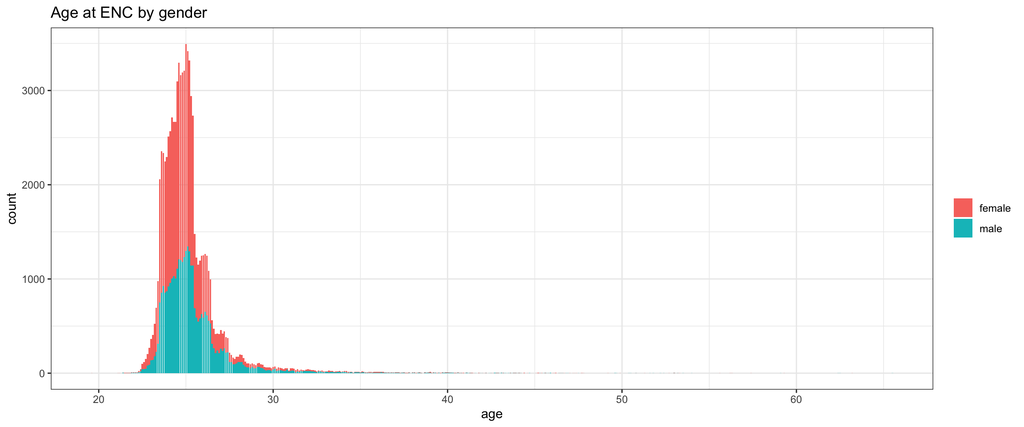

Median age at ECN was 25.2 y.o. and was significantly different by gender (female : 25.0 y.o versus male : 25.4 y.o, p<0.0001)

Top first names showed little diversity (@ASHP to compare to top first names by year)

```
## # A tibble: 20 x 2
## # Groups:   first_name_short4 [20]
##    first_name_short4     n
##    <chr>             <int>
##  1 marie              2236
##  2 anne               1425
##  3 camille            1248
##  4 marion             1119
##  5 claire             1039
##  6 pauline            1033
##  7 julie              1012
##  8 mathilde            869
##  9 sophie              849
## 10 caroline            830
## 11 marine              828
## 12 charlotte           806
## 13 helene              671
## 14 sarah               665
## 15 aurelie             619
## 16 emilie              611
## 17 celine              606
## 18 laura               598
## 19 cecile              577
## 20 audrey              566
```

```
## # A tibble: 20 x 2
## # Groups:   first_name_short4 [20]
##    first_name_short4     n
##    <chr>             <int>
##  1 pierre             1393
##  2 thomas             1110
##  3 nicolas            1072
##  4 guillaume           985
##  5 jean                930
##  6 julien              900
##  7 antoine             894
##  8 alexandre           877
##  9 romain              665
## 10 maxime              658
## 11 vincent             622
## 12 benjamin            589
## 13 clement             557
## 14 francois            499
## 15 paul                498
## 16 adrien              445
## 17 matthieu            434
## 18 quentin             431
## 19 mathieu             412
## 20 olivier             400
```

## Ranking at ENC

Males were overrepresented in the extremes quantiles when compared with the middle quantiles were females were overrepresented in comparison

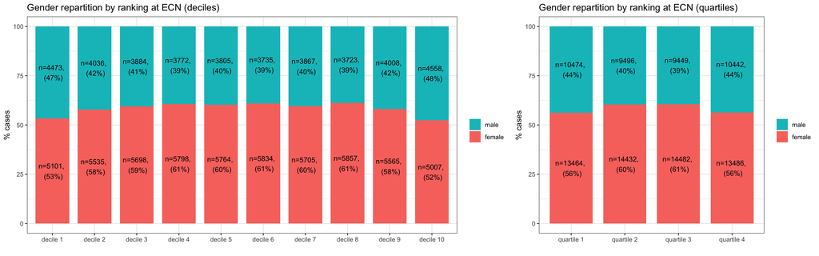

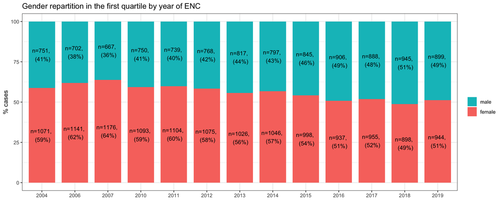

# Hospitalo universitary file

File found of the site of the CNG by Fabien https://www.cng.sante.fr/sites/default/files/Fichiers/Personnels%20enseignants%20et%20hospitaliers/HU-Liste%20electorale%20au%20%2020%20juin%202019%20final%20publi%C3%A9%20au%2024%20juin%202019.pdf downloaded the 30 march. This lists persons voting for the commission statutaire nationale (CSN) at the date of 24 june 2019.

Overall, 6164 persons were present in the list.

Gender balance favored males in a 70.1/29.9% ratio.

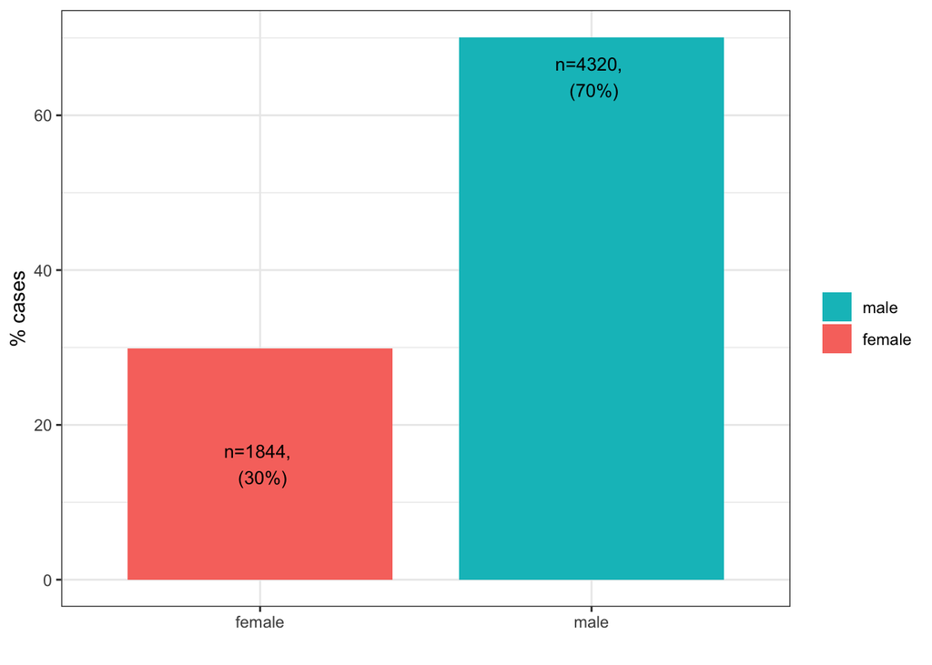

Though women represented 58% of the total of ECN candidates between 2004 and 2019, they represented only 29.8% of those who were admitted to university in this time period.

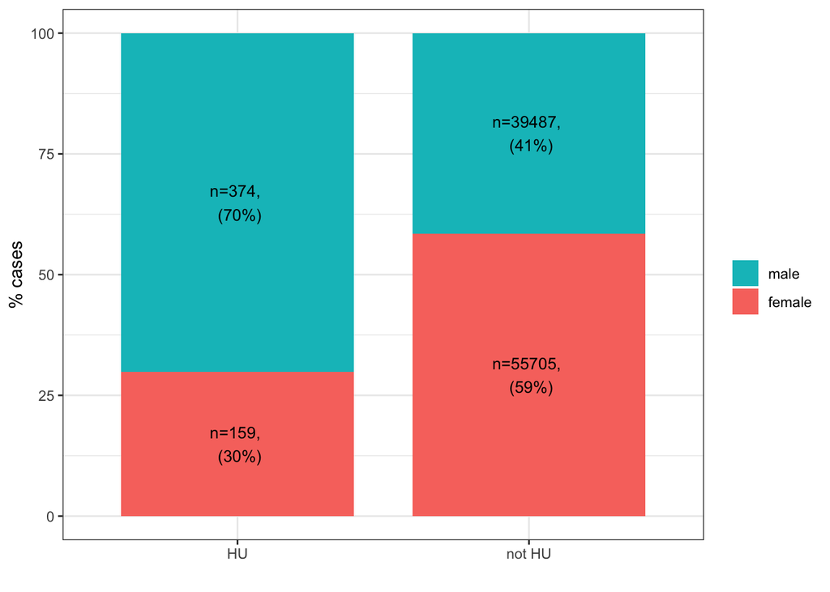

Analysis by year did not show a clear trend accross years.

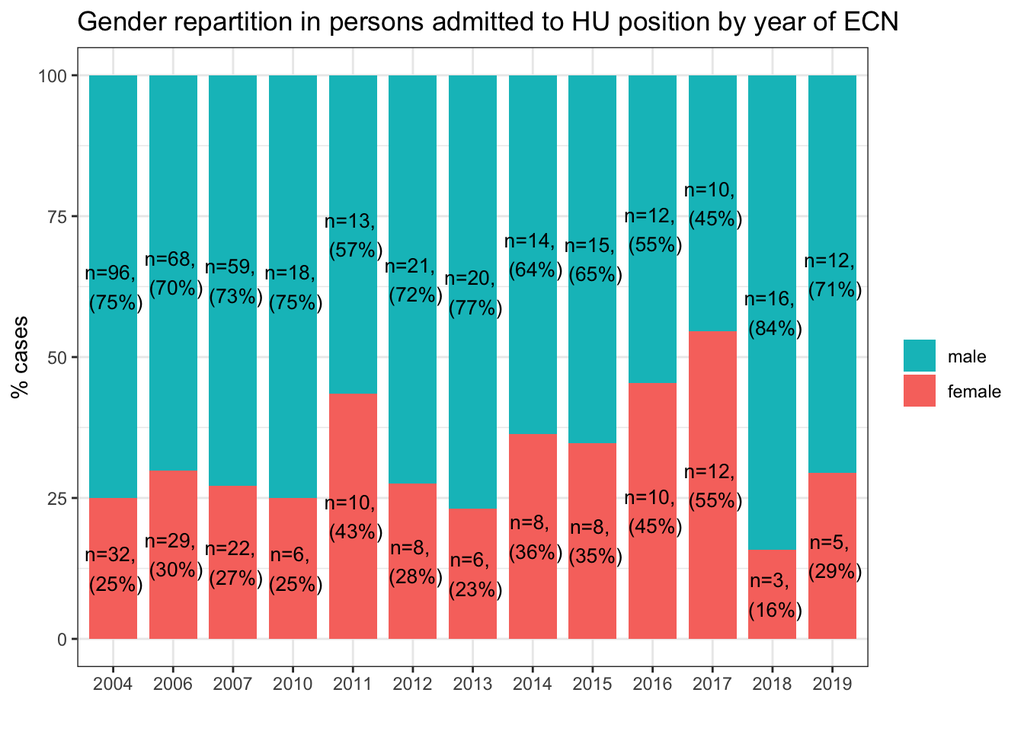

Among those who were admitted in HU position, the quantiles at ECN were represented similarly in males and females, with an overrepresentation of the 3 first deciles admitted in HU positions.

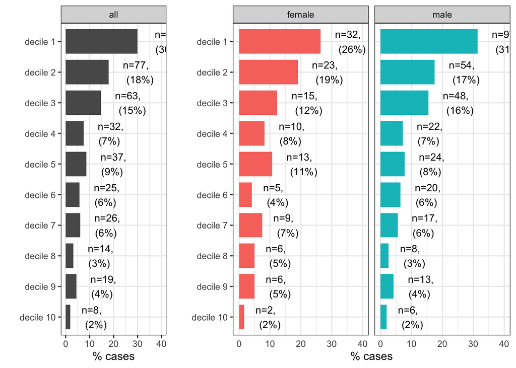